# Statistical Rethinking (Code)

Chapter 12

April, 2017

Code from *Statistical Rethinking* modified by R Pruim is shown below. Differences to the oringal include:

- a preference for putting data into containers (data frames, mostly), rather than working with lose vectors.
- use of `ggplot2` (via `ggformula`) rather than base graphics
- use of `tidyverse` for data transformation
- better (in my opinion) naming conventions

### Side note on lists, data frames, and matrices

As our models become more complicated, the containers used to store the data we use to fit the model and the data we generate from the model (using `link()`, `sim()`, and `extract.samples()`, for example) also be come more complicated. Lists, data frames, and matrices are the containers we will use the most.

- **lists** are a very general container. Items in a list are ordered and may be named as well. Each item can contain anything, including data frames, matrices, or other lists. Some lists can be converted to data frames using `as.data.frame()`, but this only works if the items in the list have the right shape.
- **data frames** are implemented as specialized lists. This means that you can use a data frame in places where are list is required, but not vice versa. Each item in a data frame must be of the same length. In most cases each item will be a vector. The individual vectors may have different types (character, integer, numeric, etc.). It is useful to imagine a data frame as a rectangular array with a column for each variable and a row for each case.
- **matrices** are also rectangular, but there is an additional restriction: each item must be of the same type (typically numeric or integer). Rows and columns are numbered starting at 1. They may also be named (but often are not). If `a` is an array, then `a[i,j]` is the element in row `i` column `j`; `a[i, ]` is row `i`, and `a[, j]` is column `j`. `apply()` can be used to apply a function to rows or columns in a matrix. The main place we have seen matrices in in the output from `link()` and `sim()`.  
  Since matrices are rectangular, they can be converted to data frames using `as.data.frame()`.
- `str()` can be used to inspect the structure of an object. This will tell you what sort of thing you have and its size.
- **matrix in a list**. We have seen this before, but it is going to become more common with the models in this chapter. Multi-level models typically include a number of related paramters that obtain an index. In this case `extract.samples()` will return a list of posterior samples for each “paramter”. Individual paramters will have a vector of posterior samples. The related parameters will be stored in a matrix with a column for each index and a row for each posterior sample. `as.data.frame()` will append the index onto the base name for these parameters.
- A note about **names**: It is awkward for R names to include symbols that are usually used for syntax – symbols like `[` and `]` for example. By default, `as.data.frame()` will convert these names, often inserting some dots (`.`) in place of the offending symbols. You can override this default, or modify the names later. To see or modify the names use `names()`, `rownames()`, or `colnames()` (If you do want to use names with those symbols, you will need to surround them in backquotes each time you use them.)

## Reed Frogs

Tadpoles really. Let’s return to our example about survival rates of tadpoles in various tanks.

#### R Code 12.1

```r
library(rethinking)
data(reedfrogs)
Frogs <- reedfrogs %>%
  mutate(tank = 1:n())   # make the tank cluster variable
glimpse(Frogs)
```

```
## Observations: 48
## Variables: 6
## $ density  <int> 10, 10, 10, 10, 10, 10, 10, 10, 10, 10, 10, 10, 10, 1...
## $ pred     <fctr> no, no, no, no, no, no, no, no, pred, pred, pred, pr...
## $ size     <fctr> big, big, big, big, small, small, small, small, big,...
## $ surv     <int> 9, 10, 7, 10, 9, 9, 10, 9, 4, 9, 7, 6, 7, 5, 9, 9, 24...
## $ propsurv <dbl> 0.90, 1.00, 0.70, 1.00, 0.90, 0.90, 1.00, 0.90, 0.40,...
## $ tank     <int> 1, 2, 3, 4, 5, 6, 7, 8, 9, 10, 11, 12, 13, 14, 15, 16...
```

#### R Code 12.2

```r
# fit
m12.1 <-
  map2stan(
    alist(
      surv ~ dbinom(density, p),
      logit(p) <- a_tank[tank],
      a_tank[tank] ~ dnorm(0, 5)
    ),
    data = Frogs,
    refresh = 0)
```

```
##
##  Elapsed Time: 0.199797 seconds (Warm-up)
##                0.193585 seconds (Sampling)
##                0.393382 seconds (Total)
##
##
## WARNING: No variance estimation is
##          performed for num_warmup < 20
##
##
## Chain 1, Iteration: 1 / 1 [100%]  (Sampling)
##  Elapsed Time: 4e-06 seconds (Warm-up)
##                0.000114 seconds (Sampling)
##                0.000118 seconds (Total)
```

```
## Computing WAIC
```

```
## Constructing posterior predictions
```

```
## [ 100 / 1000 ]
[ 200 / 1000 ]
[ 300 / 1000 ]
[ 400 / 1000 ]
[ 500 / 1000 ]
[ 600 / 1000 ]
[ 700 / 1000 ]
[ 800 / 1000 ]
[ 900 / 1000 ]
[ 1000 / 1000 ]
```

```
## Aggregated binomial counts detected. Splitting to 0/1 outcome for WAIC calculation.
```

#### R Code 12.3

```r
m12.2 <-
  map2stan(
    alist(
      surv ~ dbinom(density, p),
      logit(p) <- a_tank[tank],
      a_tank[tank] ~ dnorm(a, sigma),
      a ~ dnorm(0, 1),
      sigma ~ dcauchy(0, 1)
    ),
    data = Frogs,
    iter = 4000,
    chains = 4,
    refresh = 0
  )
```

```
##
##  Elapsed Time: 0.349339 seconds (Warm-up)
##                0.223986 seconds (Sampling)
##                0.573325 seconds (Total)
##
##
##  Elapsed Time: 0.360502 seconds (Warm-up)
##                0.221815 seconds (Sampling)
##                0.582317 seconds (Total)
```

```
## The following numerical problems occurred the indicated number of times on chain 2
```

```
##                                                                                 count
## Exception thrown at line 17: normal_log: Scale parameter is 0, but must be > 0!     1
```

```
## When a numerical problem occurs, the Hamiltonian proposal gets rejected.
```

```
## See http://mc-stan.org/misc/warnings.html#exception-hamiltonian-proposal-rejected
```

```
## If the number in the 'count' column is small, there is no need to ask about this message on stan-users.
```

```
##
##  Elapsed Time: 0.337222 seconds (Warm-up)
##                0.22138 seconds (Sampling)
##                0.558602 seconds (Total)
##
##
##  Elapsed Time: 0.330003 seconds (Warm-up)
##                0.231151 seconds (Sampling)
##                0.561154 seconds (Total)
##
##
## WARNING: No variance estimation is
##          performed for num_warmup < 20
##
##
## Chain 1, Iteration: 1 / 1 [100%]  (Sampling)
##  Elapsed Time: 4e-06 seconds (Warm-up)
##                6.9e-05 seconds (Sampling)
##                7.3e-05 seconds (Total)
```

```
## Computing WAIC
```

```
## Constructing posterior predictions
```

```
## [ 800 / 8000 ]
[ 1600 / 8000 ]
[ 2400 / 8000 ]
[ 3200 / 8000 ]
[ 4000 / 8000 ]
[ 4800 / 8000 ]
[ 5600 / 8000 ]
[ 6400 / 8000 ]
[ 7200 / 8000 ]
[ 8000 / 8000 ]
```

```
## Aggregated binomial counts detected. Splitting to 0/1 outcome for WAIC calculation.
```

#### R Code 12.4

```r
compare(m12.1, m12.2)
```

```
##         WAIC pWAIC dWAIC weight    SE dSE
## m12.2 1010.4  38.2   0.0      1 38.00  NA
## m12.1 1023.2  49.3  12.8      0 42.95 6.7
```

#### R Code 12.5

```r
# extract Stan samples
m12.2_post <- extract.samples(m12.2)

# compute median intercept for each tank and transform with logistic()
Frogs <- Frogs %>%
  mutate(
    propsurv.est = logistic(apply(m12.2_post$a_tank, 2, median))
  )
```

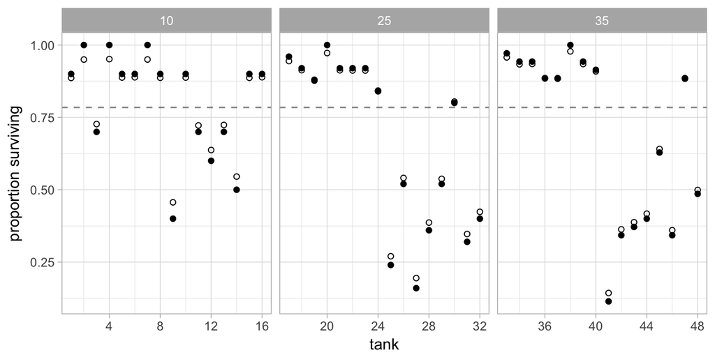

```r
gf_point(propsurv ~ tank, data = Frogs) %>%
  gf_point(propsurv.est ~ tank, data = Frogs, shape = 1) %>%
  # mark posterior median probability across tanks
  gf_hline(yintercept = logistic(median(m12.2_post$a)), lty = 2, alpha = 0.5) %>%
  gf_facet_grid( ~ density, scale="free") %>%
  gf_labs(y = "proportion surviving")
```

#### R Code 12.6

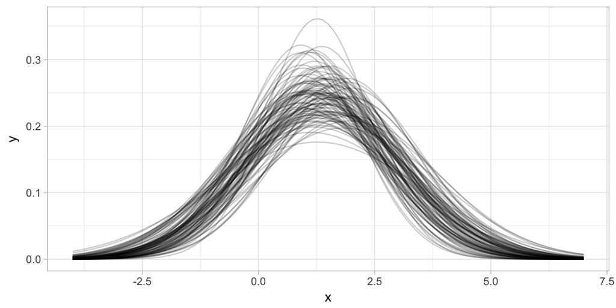

```r
# show first 100 populations in the posterior
p <-
  gf_point(y ~ x, data = data_frame(y = 0, x = -4:7), color = "transparent")

for (i in 1:100) {
  p <-
    p %>%
    gf_function(fun = dnorm,
                args = list(mean = m12.2_post$a[i], sd = m12.2_post$sigma[i]),
                alpha = 0.2)
}
p
```

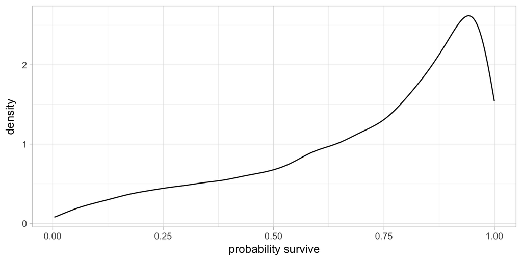

```r
# sample 8000 imaginary tanks from the posterior distribution
sim_tanks <- rnorm(8000, m12.2_post$a, m12.2_post$sigma)

# transform to probability and visualize
gf_dens( ~ (logistic(sim_tanks))) %>%
  gf_labs(x = "probability survive")
```

#### R Code 12.7-12.12

#### R Code 12

```r
FrogSim <-
  function(
    reps = 15,
    n = c(5L, 10L, 25L, 35L),
    a = 1.4,
    sigma = 1.5
    ) {
    nponds <- reps * length(n)
    expand.grid(rep = 1:reps, n = n) %>%
      mutate(
        pond = 1:nponds,
        a_true = rnorm(nponds, mean = a, sd = sigma),
        s = rbinom(nponds, prob = logistic(a_true), size = n)
      )
  }
```

#### R Code 12.10

Stan sometimes requires integer data. In R, you need to be a bit careful to ensure that you really have integers and not “numeric” (floating point) values.

```r
class(1:3)
```

```
## [1] "integer"
```

```r
class(c(1, 2, 3))
```

```
## [1] "numeric"
```

```r
class(as.integer(c(1, 2, 3)))
```

```
## [1] "integer"
```

```r
class(c(1L, 2L, 3L))  # L for Integer -- go figure
```

```
## [1] "integer"
```

#### R Code 12.13

```r
SFrogs <- FrogSim()
m12.3 <- map2stan(
  alist(
    s ~ dbinom(n, p),
    logit(p) <- a_pond[pond],
    a_pond[pond] ~ dnorm(a, sigma),
    a ~ dnorm(0, 1),
    sigma ~ dcauchy(0, 1)
  ),
  data = SFrogs,
  iter = 1e4,
  warmup = 1000,
  refresh = 0
)
```

```
##
##  Elapsed Time: 0.239542 seconds (Warm-up)
##                1.23809 seconds (Sampling)
##                1.47763 seconds (Total)
```

```
## The following numerical problems occurred the indicated number of times on chain 1
```

```
##                                                                                 count
## Exception thrown at line 17: normal_log: Scale parameter is 0, but must be > 0!     1
```

```
## When a numerical problem occurs, the Hamiltonian proposal gets rejected.
```

```
## See http://mc-stan.org/misc/warnings.html#exception-hamiltonian-proposal-rejected
```

```
## If the number in the 'count' column is small, there is no need to ask about this message on stan-users.
```

```
##
## WARNING: No variance estimation is
##          performed for num_warmup < 20
##
##
## Chain 1, Iteration: 1 / 1 [100%]  (Sampling)
##  Elapsed Time: 4e-06 seconds (Warm-up)
##                8e-05 seconds (Sampling)
##                8.4e-05 seconds (Total)
```

```
## Computing WAIC
```

```
## Constructing posterior predictions
```

```
## [ 900 / 9000 ]
[ 1800 / 9000 ]
[ 2700 / 9000 ]
[ 3600 / 9000 ]
[ 4500 / 9000 ]
[ 5400 / 9000 ]
[ 6300 / 9000 ]
[ 7200 / 9000 ]
[ 8100 / 9000 ]
[ 9000 / 9000 ]
```

```
## Aggregated binomial counts detected. Splitting to 0/1 outcome for WAIC calculation.
```

#### R Code 12.14

```r
precis(m12.3, depth = 2)
```

```
##             Mean StdDev lower 0.89 upper 0.89 n_eff Rhat
## a_pond[1]   1.40   0.87       0.02       2.74  9000    1
## a_pond[2]  -0.52   0.82      -1.75       0.81  9000    1
## a_pond[3]   2.27   1.04       0.60       3.83  9000    1
## a_pond[4]   2.28   1.04       0.64       3.86  9000    1
## a_pond[5]   0.70   0.81      -0.55       2.01  9000    1
## a_pond[6]   2.29   1.03       0.64       3.88  9000    1
## a_pond[7]   2.28   1.04       0.68       3.95  9000    1
## a_pond[8]   2.27   1.05       0.66       3.96  9000    1
## a_pond[9]   1.41   0.90      -0.08       2.75  9000    1
## a_pond[10]  0.71   0.80      -0.56       2.01  9000    1
## a_pond[11]  2.27   1.02       0.69       3.89  9000    1
## a_pond[12]  2.28   1.03       0.67       3.91  9000    1
## a_pond[13]  1.41   0.87       0.00       2.76  9000    1
## a_pond[14]  2.28   1.03       0.56       3.78  9000    1
## a_pond[15]  2.29   1.04       0.67       3.93  9000    1
## a_pond[16]  2.69   0.95       1.21       4.16  9000    1
## a_pond[17]  0.23   0.59      -0.75       1.15  9000    1
## a_pond[18]  0.97   0.64      -0.06       1.96  9000    1
## a_pond[19]  1.95   0.79       0.63       3.12  9000    1
## a_pond[20]  0.22   0.59      -0.72       1.16  9000    1
## a_pond[21]  2.70   0.97       1.20       4.21  9000    1
## a_pond[22]  1.41   0.71       0.28       2.52  9000    1
## a_pond[23]  0.58   0.60      -0.40       1.51  9000    1
## a_pond[24]  1.41   0.69       0.34       2.54  9000    1
## a_pond[25]  0.98   0.66      -0.09       2.02  9000    1
## a_pond[26]  2.68   0.93       1.23       4.15  9000    1
## a_pond[27] -1.29   0.71      -2.41      -0.19  9000    1
## a_pond[28]  1.97   0.80       0.75       3.26  9000    1
## a_pond[29]  0.60   0.60      -0.33       1.57  9000    1
## a_pond[30]  1.40   0.69       0.32       2.52  9000    1
## a_pond[31]  0.02   0.39      -0.61       0.65  9000    1
## a_pond[32]  1.20   0.45       0.45       1.88  9000    1
## a_pond[33]  0.65   0.40      -0.03       1.26  9000    1
## a_pond[34] -1.57   0.51      -2.38      -0.78  9000    1
## a_pond[35]  2.71   0.72       1.53       3.80  9000    1
## a_pond[36]  1.93   0.56       0.99       2.74  9000    1
## a_pond[37] -0.95   0.44      -1.64      -0.28  9000    1
## a_pond[38] -0.12   0.39      -0.76       0.50  9000    1
## a_pond[39] -0.44   0.40      -1.05       0.21  9000    1
```

[output cut: 8 more lines]

```
## a_pond[48] -0.79   0.36      -1.36      -0.23  9000    1
## a_pond[49]  2.00   0.49       1.21       2.77  9000    1
## a_pond[50]  0.96   0.37       0.37       1.53  9000    1
## a_pond[51]  3.51   0.85       2.20       4.83  9000    1
## a_pond[52]  0.58   0.35       0.05       1.15  9000    1
## a_pond[53]  1.10   0.39       0.53       1.74  9000    1
## a_pond[54]  2.26   0.53       1.43       3.13  9000    1
## a_pond[55]  1.10   0.38       0.52       1.74  9000    1
## a_pond[56]  0.58   0.34       0.03       1.12  9000    1
## a_pond[57]  0.83   0.36       0.26       1.38  9000    1
## a_pond[58]  1.10   0.38       0.49       1.69  9000    1
## a_pond[59]  0.70   0.35       0.16       1.27  9000    1
## a_pond[60]  0.82   0.35       0.28       1.39  9000    1
## a           1.15   0.21       0.83       1.48  9000    1
## sigma       1.35   0.19       1.03       1.64  3088    1
```

#### R Code 12.15-12.17

By combining this code into a function, we can apply it again later without retyping. This

- makes it clearer what is going on, and
- makes it easier to make systematic changes.

```r
frog_plot <- function(model, data = model@data) {
  data <-
    data %>% as.data.frame() %>%
    mutate(
      a_pond_est = as.numeric(coef(model)[1:60]),
      p_est = logistic(a_pond_est),
      p_true = logistic(a_true),
      p_raw = s / n,
      nopool_error = abs(p_raw - p_true),
      partpool_error = abs(p_est - p_true)
    )
  gf_point(nopool_error ~ pond, data = data, shape = 16) %>%
    gf_point(partpool_error ~ pond, data = data, shape = 1) %>%
    gf_line(partpool_error ~ pond,
            data = data %>% group_by(n) %>%
              mutate(partpool_error = mean(partpool_error)),
            linetype = "dashed", color = "navy") %>%
    gf_line(nopool_error ~ pond,
            data = data %>% group_by(n) %>%
              mutate(nopool_error = mean(nopool_error)),
            linetype = "dotted", color = "red") %>%
    gf_facet_grid( ~ n, scale = "free") %>%
    gf_labs(y = "absolute error")
}
```

Generating a plot from a model is a one-liner now:

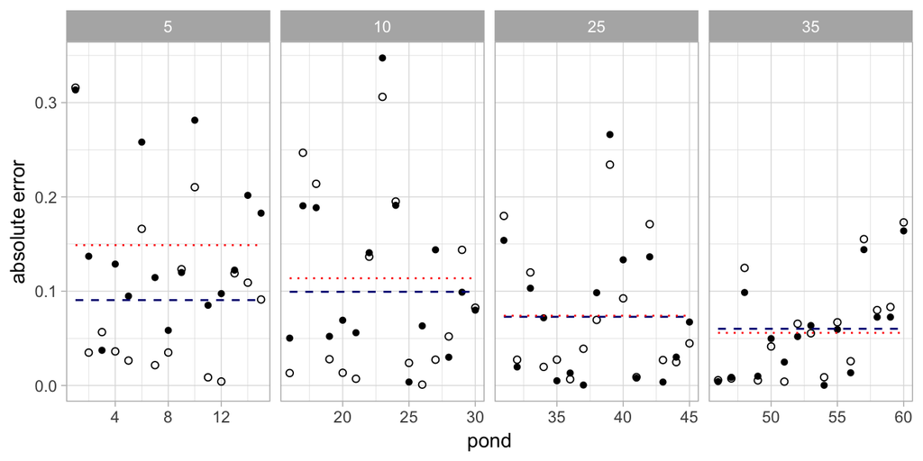

```r
frog_plot(model = m12.3)
```

#### R Code 12.19

```r
NewData <- FrogSim()
m12.3new <-
  map2stan(
    m12.3,
    data = NewData,
    iter = 1e4,
    warmup = 1000)
```

```
##
##
## Chain 1, Iteration:    1 / 10000 [  0%]  (Warmup)
## Chain 1, Iteration: 1000 / 10000 [ 10%]  (Warmup)
## Chain 1, Iteration: 1001 / 10000 [ 10%]  (Sampling)
## Chain 1, Iteration: 2000 / 10000 [ 20%]  (Sampling)
## Chain 1, Iteration: 3000 / 10000 [ 30%]  (Sampling)
## Chain 1, Iteration: 4000 / 10000 [ 40%]  (Sampling)
## Chain 1, Iteration: 5000 / 10000 [ 50%]  (Sampling)
## Chain 1, Iteration: 6000 / 10000 [ 60%]  (Sampling)
## Chain 1, Iteration: 7000 / 10000 [ 70%]  (Sampling)
## Chain 1, Iteration: 8000 / 10000 [ 80%]  (Sampling)
## Chain 1, Iteration: 9000 / 10000 [ 90%]  (Sampling)
## Chain 1, Iteration: 10000 / 10000 [100%]  (Sampling)
##  Elapsed Time: 0.253588 seconds (Warm-up)
##                1.24273 seconds (Sampling)
##                1.49631 seconds (Total)
```

```
## The following numerical problems occurred the indicated number of times on chain 1
```

```
##                                                                                 count
## Exception thrown at line 17: normal_log: Scale parameter is 0, but must be > 0!     1
```

```
## When a numerical problem occurs, the Hamiltonian proposal gets rejected.
```

```
## See http://mc-stan.org/misc/warnings.html#exception-hamiltonian-proposal-rejected
```

```
## If the number in the 'count' column is small, there is no need to ask about this message on stan-users.
```

```
##
## WARNING: No variance estimation is
##          performed for num_warmup < 20
##
##
## Chain 1, Iteration: 1 / 1 [100%]  (Sampling)
##  Elapsed Time: 6e-06 seconds (Warm-up)
##                7.5e-05 seconds (Sampling)
##                8.1e-05 seconds (Total)
```

```
## Computing WAIC
```

```
## Constructing posterior predictions
```

```
## [ 900 / 9000 ]
[ 1800 / 9000 ]
[ 2700 / 9000 ]
[ 3600 / 9000 ]
[ 4500 / 9000 ]
[ 5400 / 9000 ]
[ 6300 / 9000 ]
[ 7200 / 9000 ]
[ 8100 / 9000 ]
[ 9000 / 9000 ]
```

```
## Aggregated binomial counts detected. Splitting to 0/1 outcome for WAIC calculation.
```

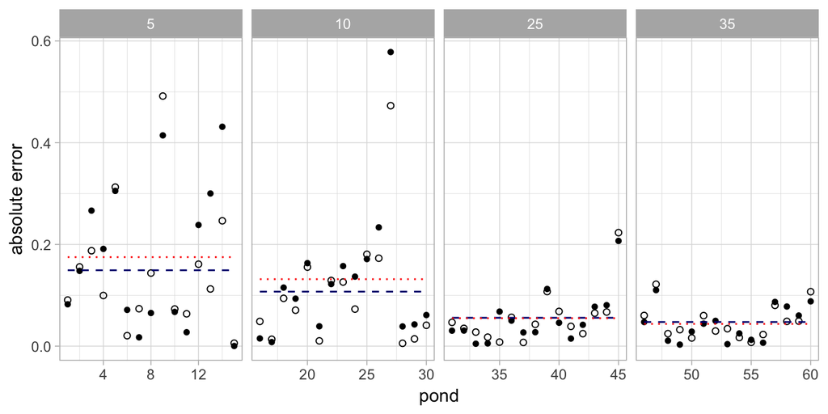

```r
frog_plot(m12.3new)
```

#### R Code 12

```r
y1 <- rnorm(1e4, 10, 1)
y2 <- 10 + rnorm(1e4, 0, 1)
```

#### R Code 12

```r
library(rethinking)
data(chimpanzees)
Chimps <- chimpanzees %>% select(-recipient)   # get rid of NAs


m12.4 <- map2stan(
  alist(
    pulled_left ~ dbinom(1, p),
    logit(p) <-
      a + a_actor[actor] + (bp + bpC * condition) * prosoc_left,
    a_actor[actor] ~ dnorm(0, sigma_actor),
    a ~ dnorm(0, 10),
    bp ~ dnorm(0, 10),
    bpC ~ dnorm(0, 10),
    sigma_actor ~ dcauchy(0, 1)
  ),
  data = Chimps,
  warmup = 1000,
  iter = 5000,
  chains = 4,
  cores = 3,
  refresh = 0
)
```

```
##
## WARNING: No variance estimation is
##          performed for num_warmup < 20
##
##
## Chain 1, Iteration: 1 / 1 [100%]  (Sampling)
##  Elapsed Time: 3e-06 seconds (Warm-up)
##                0.00027 seconds (Sampling)
##                0.000273 seconds (Total)
```

```
## Computing WAIC
```

```
## Constructing posterior predictions
```

```
## [ 1600 / 16000 ]
[ 3200 / 16000 ]
[ 4800 / 16000 ]
[ 6400 / 16000 ]
[ 8000 / 16000 ]
[ 9600 / 16000 ]
[ 11200 / 16000 ]
[ 12800 / 16000 ]
[ 14400 / 16000 ]
[ 16000 / 16000 ]
```

#### R Code 12.22

```r
m12.4_post <- extract.samples(m12.4)
m12.4_post <-
  m12.4_post %>%
  as.data.frame() %>%
  bind_cols(
    sapply(1:7, function(actor)
      m12.4_post$a + m12.4_post$a_actor[, actor]) %>%
      as.data.frame() %>%
      setNames(paste0("total_a.", 1:7))
  )
```

#### R Code 12.23

```r
# prep data
Chimps <-
  Chimps %>% rename(block_id = block)   # name 'block' is reserved by Stan

m12.5 <- map2stan(
  alist(
    pulled_left ~ dbinom(1, p),
    logit(p) <- a + a_actor[actor] + a_block[block_id] +
      (bp + bpc * condition) * prosoc_left,
    a_actor[actor] ~ dnorm(0, sigma_actor),
    a_block[block_id] ~ dnorm(0, sigma_block),
    c(a, bp, bpc) ~ dnorm(0, 10),
    sigma_actor ~ dcauchy(0, 1),
    sigma_block ~ dcauchy(0, 1)
  ),
  data = Chimps,
  warmup = 1000,
  iter = 6000,
  chains = 4,
  cores = 3,
  refresh = 0
)
```

```
##
## WARNING: No variance estimation is
##          performed for num_warmup < 20
##
##
## Chain 1, Iteration: 1 / 1 [100%]  (Sampling)
##  Elapsed Time: 3e-06 seconds (Warm-up)
##                0.000302 seconds (Sampling)
##                0.000305 seconds (Total)
```

```
## Computing WAIC
```

```
## Constructing posterior predictions
```

```
## [ 2000 / 20000 ]
[ 4000 / 20000 ]
[ 6000 / 20000 ]
[ 8000 / 20000 ]
[ 10000 / 20000 ]
[ 12000 / 20000 ]
[ 14000 / 20000 ]
[ 16000 / 20000 ]
[ 18000 / 20000 ]
[ 20000 / 20000 ]
```

#### R Code 12.24

```r
precis(m12.5, depth = 2) # depth=2 displays varying effects
```

```
##              Mean StdDev lower 0.89 upper 0.89 n_eff Rhat
## a_actor[1]  -1.18   0.99      -2.61       0.37  3179    1
## a_actor[2]   4.19   1.68       1.84       6.44  5553    1
## a_actor[3]  -1.49   0.99      -2.94       0.02  3202    1
## a_actor[4]  -1.49   0.99      -2.99      -0.03  3204    1
## a_actor[5]  -1.18   0.99      -2.60       0.35  3183    1
## a_actor[6]  -0.23   0.99      -1.71       1.26  3173    1
## a_actor[7]   1.31   1.01      -0.20       2.85  3431    1
## a_block[1]  -0.18   0.23      -0.53       0.11  4413    1
## a_block[2]   0.04   0.19      -0.25       0.34  8550    1
## a_block[3]   0.05   0.20      -0.24       0.36  7894    1
## a_block[4]   0.01   0.19      -0.29       0.29  8840    1
## a_block[5]  -0.03   0.19      -0.33       0.25 10161    1
## a_block[6]   0.11   0.21      -0.17       0.43  4821    1
## a            0.46   0.98      -1.00       1.93  3117    1
## bp           0.83   0.26       0.40       1.24 11794    1
## bpc         -0.14   0.30      -0.61       0.35 11036    1
## sigma_actor  2.29   0.96       1.08       3.49  4513    1
## sigma_block  0.22   0.18       0.01       0.44  2350    1
```

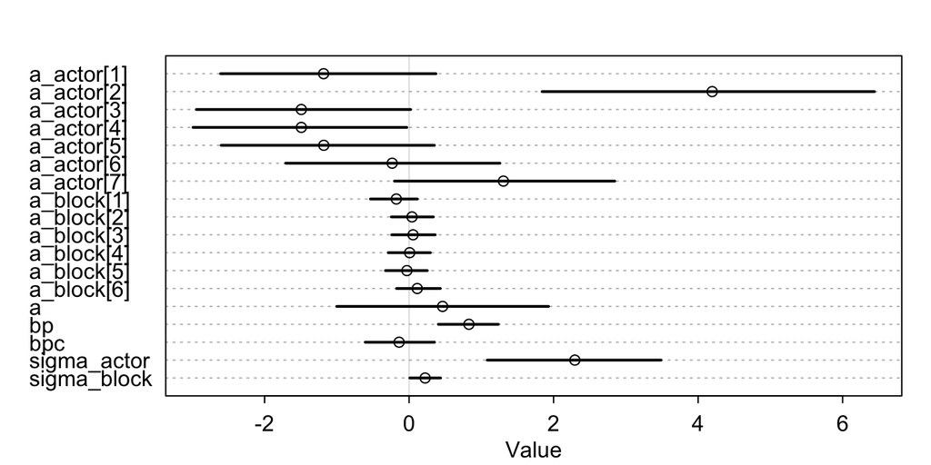

```r
plot(precis(m12.5, depth = 2)) # also plot
```

#### R Code 12.25

```r
m12.5_post <- extract.samples(m12.5) %>% data.frame()
names(m12.5_post)
```

```
##  [1] "a_actor.1"   "a_actor.2"   "a_actor.3"   "a_actor.4"   "a_actor.5"
##  [6] "a_actor.6"   "a_actor.7"   "a_block.1"   "a_block.2"   "a_block.3"
## [11] "a_block.4"   "a_block.5"   "a_block.6"   "a"           "bp"
## [16] "bpc"         "sigma_actor" "sigma_block"
```

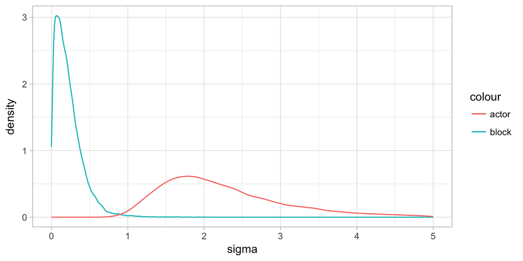

```r
gf_dens(~sigma_block + color::"block", data = m12.5_post) %>%
  gf_dens(~sigma_actor + color::"actor", data = m12.5_post) %>%
  gf_labs(x = "sigma") %>%
  gf_lims(x = c(0,5))
```

If we convert our posterior samples from a “wide” format (one row per sample) to a “long” format (one row for each sample of each parameter, we can plot posterior distributions for multiple parameters even more easily.

```r
m12.5_post_long <-  m12.5_post %>%
          tidyr::gather(param, value)
m12.5_post_long %>% head(3)
```

```
##       param      value
## 1 a_actor.1 -0.7577768
## 2 a_actor.1 -1.6615420
## 3 a_actor.1 -0.2182848
```

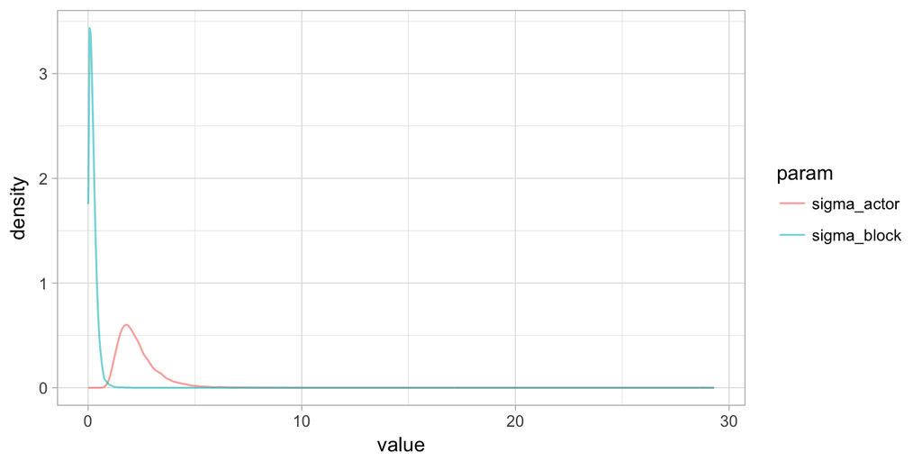

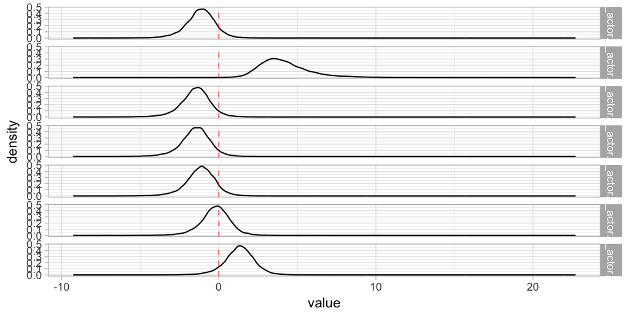

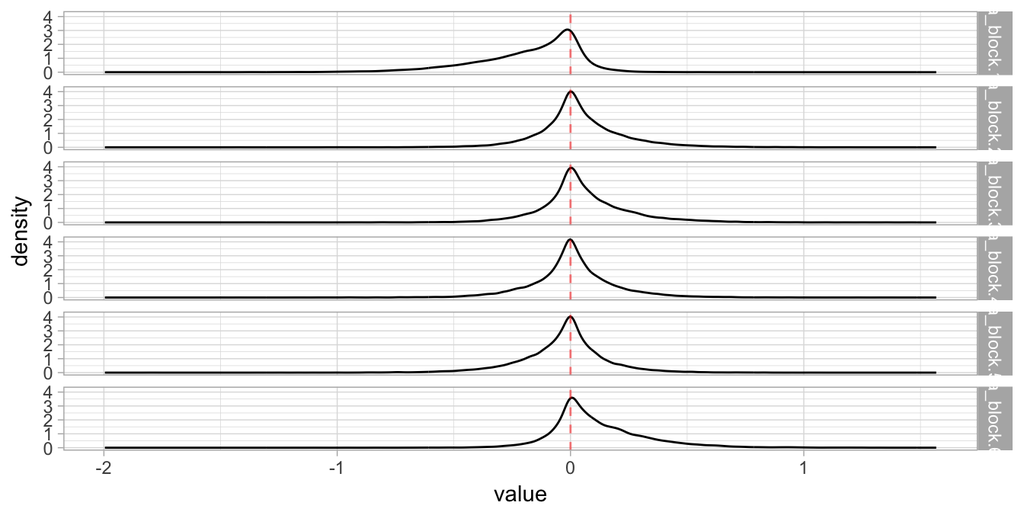

```r
gf_dens(~ value + color::param, alpha = 0.6,
        data = m12.5_post_long %>% filter(grepl("sigma", param)))
gf_dens(~ value,
        data = m12.5_post_long %>% filter(grepl("a_actor\\.", param))) %>%
  gf_vline(xintercept = 0, color = "red", alpha = 0.5, linetype = "dashed") %>%
  gf_facet_grid( param ~ .)
gf_dens(~ value,
        data = m12.5_post_long %>% filter(grepl("a_block\\.", param))) %>%
  gf_vline(xintercept = 0, color = "red", alpha = 0.5, linetype = "dashed") %>%
  gf_facet_grid( param ~ .)
```

#### R Code 12.26

```r
compare(m12.4, m12.5)
```

```
##        WAIC pWAIC dWAIC weight    SE  dSE
## m12.4 531.6   8.2     0   0.62 19.48   NA
## m12.5 532.6  10.3     1   0.38 19.67 1.73
```

#### R Code 12.27

```r
m12.4_pred <-
  expand.grid(
    prosoc_left = 0:1,
    condition = 0:1,
    actor = 1:7) %>%
  mutate(
    combo = paste0(prosoc_left, "/", condition)
  )

link.m12.4 <- link(m12.4, data = m12.4_pred)
```

```
## [ 100 / 1000 ]
[ 200 / 1000 ]
[ 300 / 1000 ]
[ 400 / 1000 ]
[ 500 / 1000 ]
[ 600 / 1000 ]
[ 700 / 1000 ]
[ 800 / 1000 ]
[ 900 / 1000 ]
[ 1000 / 1000 ]
```

```r
m12.4_pred <- m12.4_pred %>%
  mutate(
    p.pred = apply(link.m12.4, 2, mean),
    p.link.lo = apply(link.m12.4, 2, PI)[1,],
    p.link.hi = apply(link.m12.4, 2, PI)[2,]
  )
```

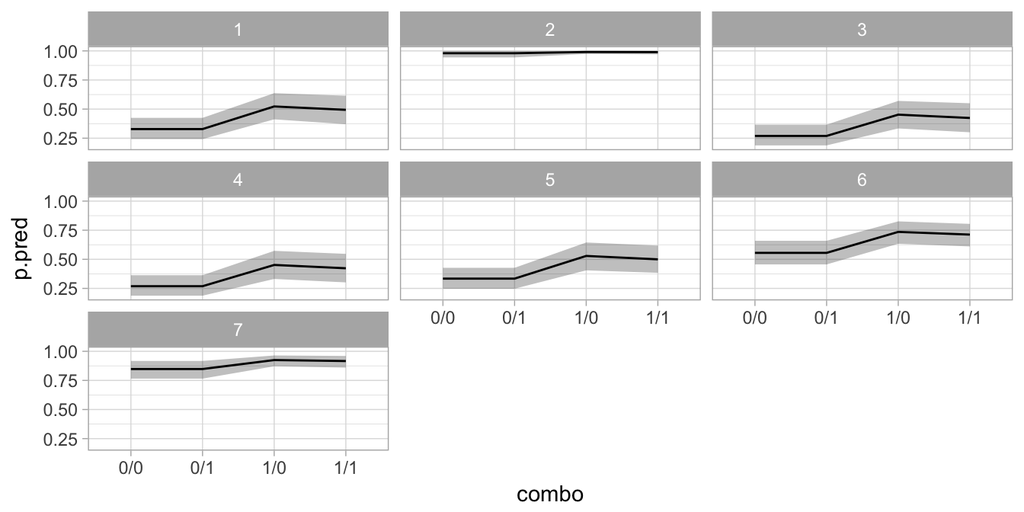

```r
gf_ribbon(p.link.lo + p.link.hi ~ combo + group::"1", data = m12.4_pred) %>%
  gf_line(p.pred ~ combo + group::"1", data = m12.4_pred) %>%
  gf_facet_wrap( ~ actor)
```

#### R Code 12.28

```r
m12.4_post <- extract.samples(m12.4)
m12.4_postD <- m12.4_post %>% data.frame()
str(m12.4_post)
```

```
## List of 5
##  $ a_actor    : num [1:16000, 1:7] -0.524 -0.439 -1.049 -2.072 -0.788 ...
##  $ a          : num [1:16000(1d)] -0.944 -0.239 0.387 1.357 0.243 ...
##  $ bp         : num [1:16000(1d)] 0.779 1.177 0.476 0.662 0.849 ...
##  $ bpC        : num [1:16000(1d)] 0.0606 -0.2247 0.0883 0.0809 -0.2215 ...
##  $ sigma_actor: num [1:16000(1d)] 2.82 1.74 2.84 3.11 2.48 ...
```

```r
str(m12.4_postD)
```

```
## 'data.frame':    16000 obs. of  11 variables:
##  $ a_actor.1  : num  -0.524 -0.439 -1.049 -2.072 -0.788 ...
##  $ a_actor.2  : num  5.82 4.31 3.94 6.23 3.39 ...
##  $ a_actor.3  : num  -0.00768 -1.19026 -1.24824 -2.19619 -1.29545 ...
##  $ a_actor.4  : num  0.153 -1.03 -1.243 -2.724 -1.647 ...
##  $ a_actor.5  : num  0.156 -0.976 -0.556 -1.938 -1.128 ...
##  $ a_actor.6  : num  1.151 0.386 -0.11 -0.868 -0.17 ...
##  $ a_actor.7  : num  3.41 2.47 1.296 0.686 1.638 ...
##  $ a          : num [1:16000(1d)] -0.944 -0.239 0.387 1.357 0.243 ...
##  $ bp         : num [1:16000(1d)] 0.779 1.177 0.476 0.662 0.849 ...
##  $ bpC        : num [1:16000(1d)] 0.0606 -0.2247 0.0883 0.0809 -0.2215 ...
##  $ sigma_actor: num [1:16000(1d)] 2.82 1.74 2.84 3.11 2.48 ...
```

#### R Code 12.29

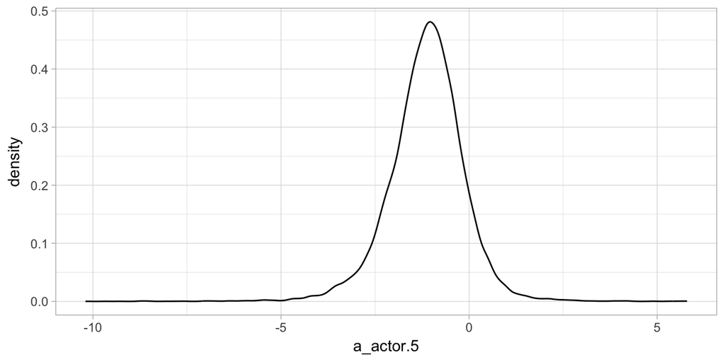

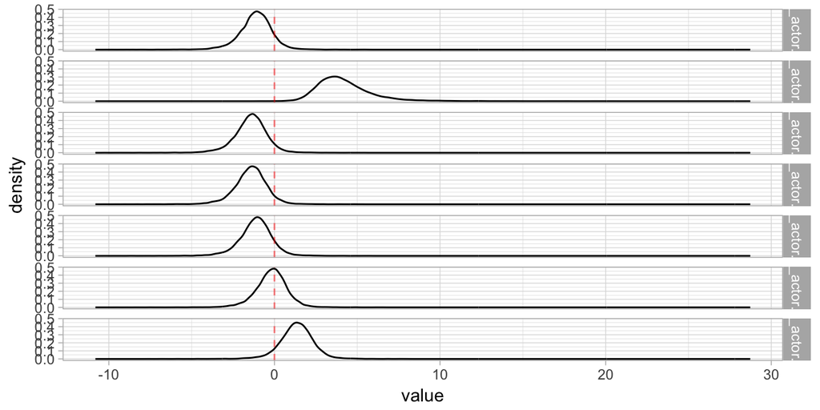

```r
gf_dens( ~ a_actor.5, data = m12.4_postD)
m12.4_post_long <-
  m12.4_postD %>%
  tidyr::gather(param, value)
gf_dens( ~ value, data = m12.4_post_long %>% filter(grepl("actor\\.", param))) %>%
  gf_vline(xintercept = 0, color = "red", alpha = 0.5, linetype = "dashed") %>%
  gf_facet_grid( param ~ .)
```

### Creating the link function manually

For some models, it is necessary to create posterior values manually rather than with `link()` or `sim()`. Although this is not required here, we illustrate the manual approach by way of comparison.

#### R Code 12.30

```r
p.link <- function(prosoc_left, condition, actor, post = m12.4_post) {
  logodds <-
    with(post,
         a + a_actor[, actor] + (bp + bpC * condition) * prosoc_left)
  return(logistic(logodds))
}
str(p.link(0, 0, 2))
```

```
##  num [1:16000(1d)] 0.992 0.983 0.987 0.999 0.974 ...
```

#### R Code 12.31

```r
G <- expand.grid(
  prosoc_left = 0:1,
  condition = 0:1,
  actor = 1:7) %>%
  mutate(
    combo = paste0(prosoc_left, "/", condition)
  )

manual_link <-
  with(G,    # saves having to type G$ repeatedly
       mapply(p.link, prosoc_left, condition, actor)
  )
# Note: a column here for each row in G
str(manual_link)
```

```
##  num [1:16000, 1:28] 0.187 0.337 0.34 0.328 0.367 ...
```

```r
dim(G)
```

```
## [1] 28  4
```

```r
manual12.4_pred <-
  G %>%
  mutate(
    p.pred = apply(manual_link, 2, mean),
    p.link.lo = apply(manual_link, 2, PI)[1,],
    p.link.hi = apply(manual_link, 2, PI)[2,]
  )
```

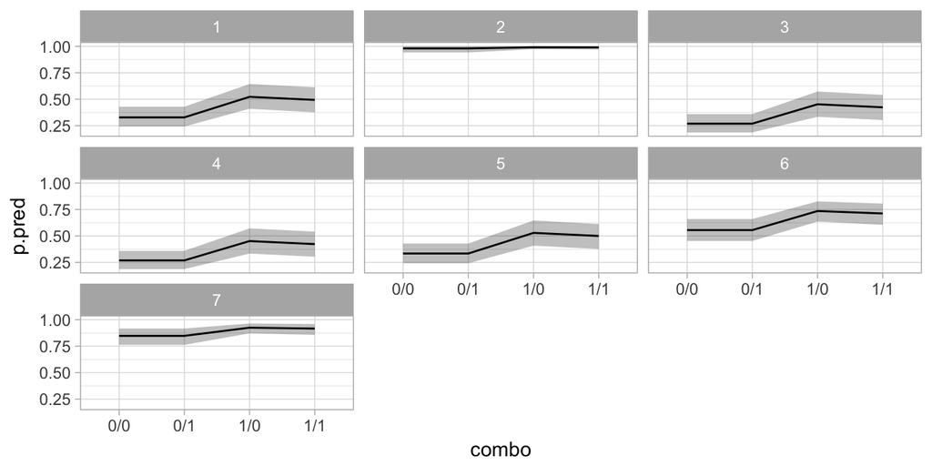

```r
# replication of plot from above using home spun link
gf_ribbon(p.link.lo + p.link.hi ~ combo + group::"1", data = manual12.4_pred) %>%
  gf_line(p.pred ~ combo + group::"1", data = m12.4_pred) %>%
  gf_facet_wrap( ~ actor)
```

#### R Code 12.32

```r
# don't need multiple actors this time
G <- expand.grid(
  prosoc_left = 0:1,
  condition = 0:1,
  actor = 1) %>%
  mutate(
    combo = paste0(prosoc_left, "/", condition)
  )
```

#### R Code 12.33

```r
# replace varying intercept samples with zeros
# 1000 samples by 7 actors
a_actor_zeros <- matrix(0, 1000, 7)
```

#### R Code 12.34

```r
# note use of replace list
m12.4_link2 <-
  link(
    m12.4,
    n = 1000,
    data = G,
    replace = list(a_actor = a_actor_zeros)
  )
```

```
## [ 100 / 1000 ]
[ 200 / 1000 ]
[ 300 / 1000 ]
[ 400 / 1000 ]
[ 500 / 1000 ]
[ 600 / 1000 ]
[ 700 / 1000 ]
[ 800 / 1000 ]
[ 900 / 1000 ]
[ 1000 / 1000 ]
```

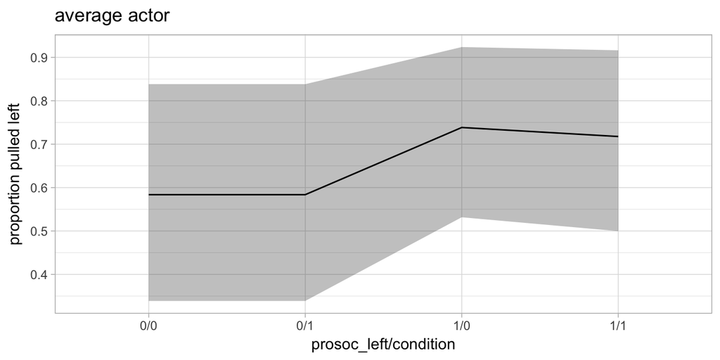

```r
m12.4_pred2 <-
  G %>%
  mutate(
    p.pred = apply(m12.4_link2, 2, mean),
    p.link.lo = apply(m12.4_link2, 2, PI, prob = 0.8)[1,],
    p.link.hi = apply(m12.4_link2, 2, PI, prob = 0.8)[2,]
  )


gf_ribbon(p.link.lo + p.link.hi ~ combo + group::"1", data = m12.4_pred2) %>%
  gf_line(p.pred ~ combo + group::"doesn't matter what this is", data = m12.4_pred2) %>%
  gf_labs(x = "prosoc_left/condition", y = "proportion pulled left", title = "average actor")
```